# week 8

# 13.4.2

Compute the average delay by destination, then join on the `airports` data frame so you can show the spatial distribution of delays. Here’s an easy way to draw a map of the United States:

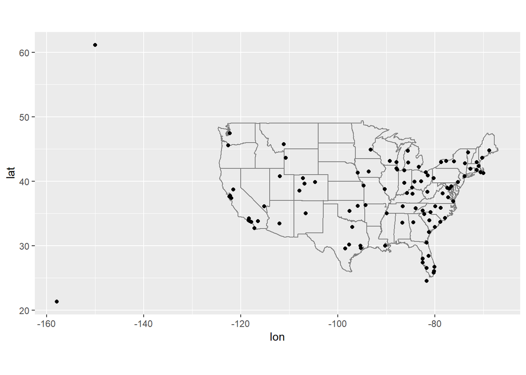

```r
airports %>%
  semi_join(flights, c("faa" = "dest")) %>%
  ggplot(aes(lon, lat)) +
  borders("state") +
  geom_point() +
  coord_quickmap()
```

(Don’t worry if you don’t understand what `semi_join()` does - you’ll learn about it next.)

You might want to use the size or color of the points to display the average delay for each airport.

```r
avg_dest_delays <-
  flights %>%
  group_by(dest) %>%
  # arrival delay NA's are cancelled flights
  summarise(delay = mean(arr_delay, na.rm = TRUE)) %>%
  inner_join(airports, by = c(dest = "faa"))
```

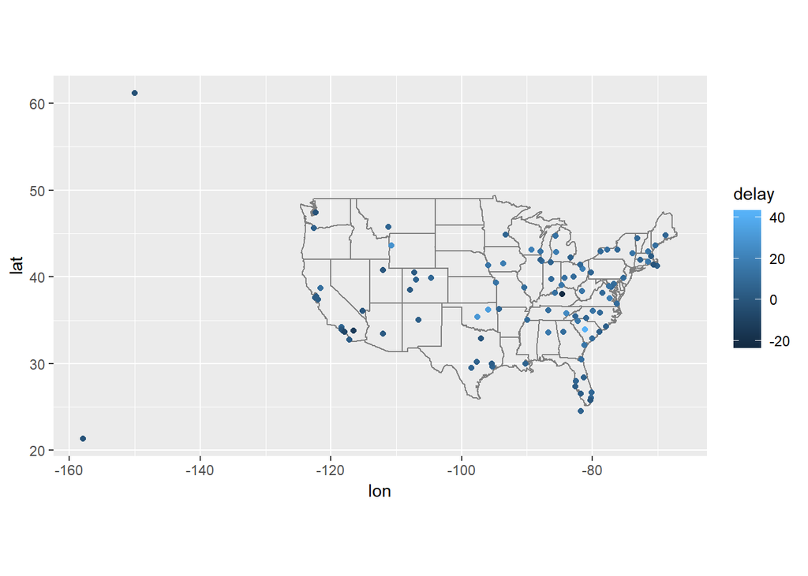

```r
avg_dest_delays %>%
  ggplot(aes(lon, lat, colour = delay)) +
  borders("state") +
  geom_point() +
  coord_quickmap()
```

# 2.Add the location of the origin and destination (i.e. the `lat` and `lon`) to `flights`.

You can perform one join after another. If duplicate variables are found, by default, dplyr will distinguish the two by adding `.x`, and `.y` to the ends of the variable names to solve naming conflicts.

```r
airport_locations <- airports %>%
  select(faa, lat, lon)
flights %>%
  select(year:day, hour, origin, dest) %>%
  left_join(
    airport_locations,
    by = c("origin" = "faa")
  ) %>%
  left_join(
    airport_locations,
    by = c("dest" = "faa")
  )
```

```
## # A tibble: 336,776 x 10
##     year month   day  hour origin dest  lat.x lon.x lat.y lon.y
##    <int> <int> <int> <dbl> <chr>  <chr> <dbl> <dbl> <dbl> <dbl>
##  1  2013     1     1     5 EWR    IAH    40.7 -74.2  30.0 -95.3
##  2  2013     1     1     5 LGA    IAH    40.8 -73.9  30.0 -95.3
##  3  2013     1     1     5 JFK    MIA    40.6 -73.8  25.8 -80.3
##  4  2013     1     1     5 JFK    BQN    40.6 -73.8  NA    NA
##  5  2013     1     1     6 LGA    ATL    40.8 -73.9  33.6 -84.4
##  6  2013     1     1     5 EWR    ORD    40.7 -74.2  42.0 -87.9
##  7  2013     1     1     6 EWR    FLL    40.7 -74.2  26.1 -80.2
##  8  2013     1     1     6 LGA    IAD    40.8 -73.9  38.9 -77.5
##  9  2013     1     1     6 JFK    MCO    40.6 -73.8  28.4 -81.3
## 10  2013     1     1     6 LGA    ORD    40.8 -73.9  42.0 -87.9
## # ... with 336,766 more rows
```

This however, this default can be over-ridden using the `suffix` argument. It is always good practice to have clear variable names, so I will use the suffixes `"_dest"` and `"_origin`" to specify whether the column refers to the destination or origin airport.

```r
airport_locations <- airports %>%
  select(faa, lat, lon)
flights %>%
  select(year:day, hour, origin, dest) %>%
  left_join(
    airport_locations,
    by = c("origin" = "faa")
  ) %>%
  left_join(
    airport_locations,
    by = c("dest" = "faa"),
    suffix = c("_origin", "_dest")
    # existing lat and lon variables in tibble gain the _origin suffix
    # new lat and lon variables are given _dest suffix
  )
```

```
## # A tibble: 336,776 x 10
##     year month   day  hour origin dest  lat_origin lon_origin lat_dest
##    <int> <int> <int> <dbl> <chr>  <chr>      <dbl>      <dbl>    <dbl>
##  1  2013     1     1     5 EWR    IAH         40.7      -74.2     30.0
##  2  2013     1     1     5 LGA    IAH         40.8      -73.9     30.0
##  3  2013     1     1     5 JFK    MIA         40.6      -73.8     25.8
##  4  2013     1     1     5 JFK    BQN         40.6      -73.8     NA
##  5  2013     1     1     6 LGA    ATL         40.8      -73.9     33.6
##  6  2013     1     1     5 EWR    ORD         40.7      -74.2     42.0
##  7  2013     1     1     6 EWR    FLL         40.7      -74.2     26.1
##  8  2013     1     1     6 LGA    IAD         40.8      -73.9     38.9
##  9  2013     1     1     6 JFK    MCO         40.6      -73.8     28.4
## 10  2013     1     1     6 LGA    ORD         40.8      -73.9     42.0
## # ... with 336,766 more rows, and 1 more variable: lon_dest <dbl>
```

# 3.Is there a relationship between the age of a plane and its delays?

The question does not specify whether the relationship is with departure delay or arrival delay. Consider lookinf for both.

```r
plane_cohorts <- inner_join(flights,
  select(planes, tailnum, plane_year = year),
  by = "tailnum"
) %>%
  mutate(age = year - plane_year) %>%
  filter(!is.na(age)) %>%
  mutate(age = pmin(25, age)) %>%
  group_by(age) %>%
  summarise(
    dep_delay_mean = mean(dep_delay, na.rm = TRUE),
    dep_delay_sd = sd(dep_delay, na.rm = TRUE),
    arr_delay_mean = mean(arr_delay, na.rm = TRUE),
    arr_delay_sd = sd(arr_delay, na.rm = TRUE),
    n_arr_delay = sum(!is.na(arr_delay)),
    n_dep_delay = sum(!is.na(arr_delay))
  )
```

I will look for a relationship between departure delay and age by plotting age against the average departure delay. The average departure delay is increasing for planes with ages up until 10 years. After that the departure delay decreases or levels off. The decrease in departure delay could be because older planes with many mechanical issues are removed from service or because air lines schedule these planes with enough time so that mechanical issues do not delay them.

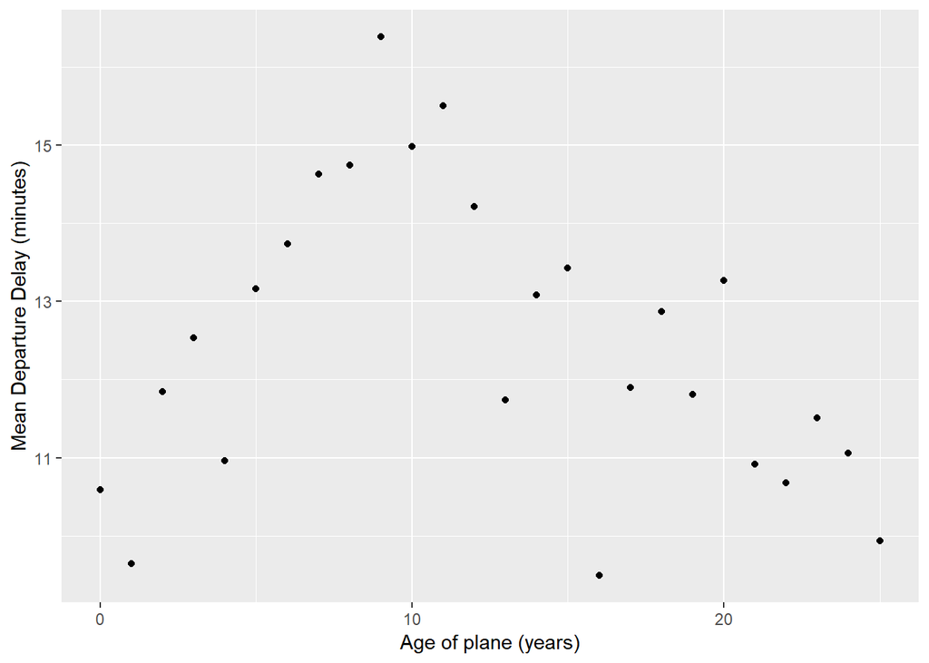

```r
ggplot(plane_cohorts, aes(x = age, y = dep_delay_mean)) +
  geom_point() +
  scale_x_continuous("Age of plane (years)", breaks = seq(0, 50, by = 10)) +
  scale_y_continuous("Mean Departure Delay (minutes)")
```

There is a similar relationship in arrival delays. Delays increase with the age of the plane until ten years, then it declines and flattens out.

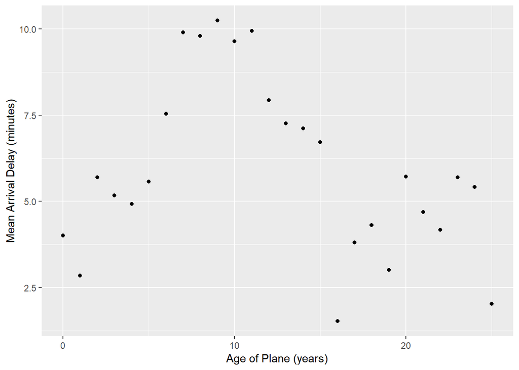

```r
ggplot(plane_cohorts, aes(x = age, y = arr_delay_mean)) +
  geom_point() +
  scale_x_continuous("Age of Plane (years)", breaks = seq(0, 50, by = 10)) +
  scale_y_continuous("Mean Arrival Delay (minutes)")
```

# 4. What weather conditions make it more likely to see a delay?

Almost any amount of precipitation is associated with a delay. However, there is not a strong a trend above 0.02 in. of precipitation.

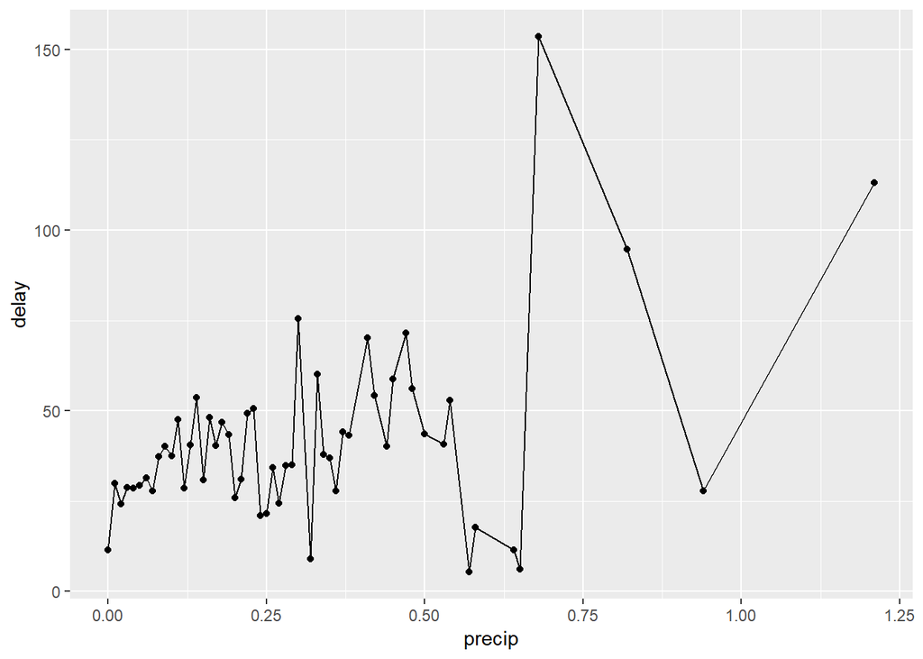

```r
flight_weather <-
  flights %>%
  inner_join(weather, by = c(
    "origin" = "origin",
    "year" = "year",
    "month" = "month",
    "day" = "day",
    "hour" = "hour"
  ))
flight_weather %>%
  group_by(precip) %>%
  summarise(delay = mean(dep_delay, na.rm = TRUE)) %>%
  ggplot(aes(x = precip, y = delay)) +
  geom_line() + geom_point()
```

# 5.What happened on June 13, 2013?

Display the spatial pattern of delays, and then use Google to cross-reference with the weather.

There was a large series of storms (derechos) in the southeastern US (see [June 12-13, 2013 derecho series](https://en.wikipedia.org/wiki/June_12%E2%80%9313,_2013_derecho_series)). The following plot show that the largest delays were in Tennessee (Nashville), the Southeast, and the Midwest, which were the locations of the derechos.

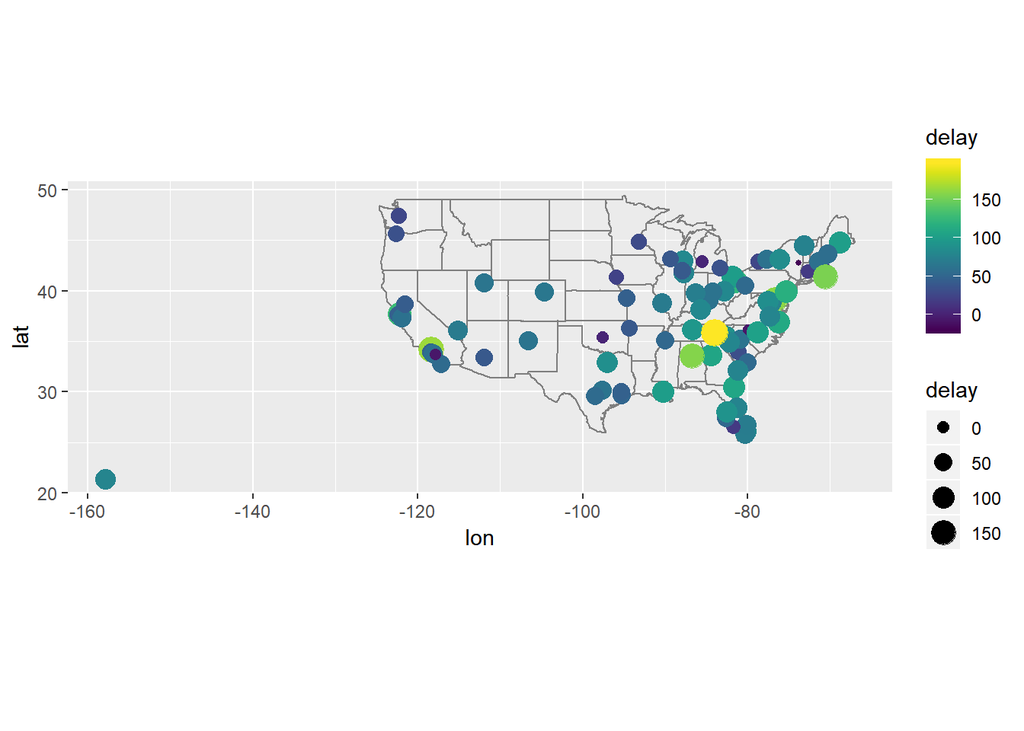

```r
flights %>%
  filter(year == 2013, month == 6, day == 13) %>%
  group_by(dest) %>%
  summarise(delay = mean(arr_delay, na.rm = TRUE)) %>%
  inner_join(airports, by = c("dest" = "faa")) %>%
  ggplot(aes(y = lat, x = lon, size = delay, colour = delay)) +
  borders("state") +
  geom_point() +
  coord_quickmap() +
  scale_colour_viridis()
```

# 13.5.1 Exercises

# 1.What does it mean for a flight to have a missing tailnum? What do the tail numbers that don’t have a matching record in planes have in common? (Hint: one variable explains ~90% of the problems.)

American Airlines (AA) and Envoy Airlines (MQ) don’t report tail numbers.

```r
flights %>%
  anti_join(planes, by = "tailnum") %>%
  count(carrier, sort = TRUE)
```

```
## # A tibble: 10 x 2
##    carrier     n
##    <chr>   <int>
##  1 MQ      25397
##  2 AA      22558
##  3 UA       1693
##  4 9E       1044
##  5 B6        830
##  6 US        699
##  7 FL        187
##  8 DL        110
##  9 F9         50
## 10 WN         38
```

# 2Filter flights to only show flights with planes that have flown at least 100 flights.

```r
planes_gte100 <-
  filter(flights) %>%
  group_by(tailnum) %>%
  count() %>%
  filter(n >= 100)
flights %>%
  semi_join(planes_gte100, by = "tailnum")
```

```
## # A tibble: 230,902 x 19
##     year month   day dep_time sched_dep_time dep_delay arr_time
##    <int> <int> <int>    <int>          <int>     <dbl>    <int>
##  1  2013     1     1      517            515         2      830
##  2  2013     1     1      533            529         4      850
##  3  2013     1     1      544            545        -1     1004
##  4  2013     1     1      554            558        -4      740
##  5  2013     1     1      555            600        -5      913
##  6  2013     1     1      557            600        -3      709
##  7  2013     1     1      557            600        -3      838
##  8  2013     1     1      558            600        -2      849
##  9  2013     1     1      558            600        -2      853
## 10  2013     1     1      558            600        -2      923
## # ... with 230,892 more rows, and 12 more variables: sched_arr_time <int>,
## #   arr_delay <dbl>, carrier <chr>, flight <int>, tailnum <chr>,
## #   origin <chr>, dest <chr>, air_time <dbl>, distance <dbl>, hour <dbl>,
## #   minute <dbl>, time_hour <dttm>
```

# 3.Combine fueleconomy::vehicles and fueleconomy::common to find only the records for the most common models.

```r
fueleconomy::vehicles %>%
  semi_join(fueleconomy::common, by = c("make", "model"))
```

```
## # A tibble: 14,531 x 12
##       id make  model   year class trans drive   cyl displ fuel    hwy   cty
##    <int> <chr> <chr>  <int> <chr> <chr> <chr> <int> <dbl> <chr> <int> <int>
##  1  1833 Acura Integ~  1986 Subc~ Auto~ Fron~     4   1.6 Regu~    28    22
##  2  1834 Acura Integ~  1986 Subc~ Manu~ Fron~     4   1.6 Regu~    28    23
##  3  3037 Acura Integ~  1987 Subc~ Auto~ Fron~     4   1.6 Regu~    28    22
##  4  3038 Acura Integ~  1987 Subc~ Manu~ Fron~     4   1.6 Regu~    28    23
##  5  4183 Acura Integ~  1988 Subc~ Auto~ Fron~     4   1.6 Regu~    27    22
##  6  4184 Acura Integ~  1988 Subc~ Manu~ Fron~     4   1.6 Regu~    28    23
##  7  5303 Acura Integ~  1989 Subc~ Auto~ Fron~     4   1.6 Regu~    27    22
##  8  5304 Acura Integ~  1989 Subc~ Manu~ Fron~     4   1.6 Regu~    28    23
##  9  6442 Acura Integ~  1990 Subc~ Auto~ Fron~     4   1.8 Regu~    24    20
## 10  6443 Acura Integ~  1990 Subc~ Manu~ Fron~     4   1.8 Regu~    26    21
## # ... with 14,521 more rows
```

Why does the above code join on `make` and `model` and not just `model`? It is possible for two car brands (`make`) to produce a car with the same name (`model`). In both the `vehicles` and `common` data we can find some examples. For example, “Truck 4WD” is produced by many different brands.

```r
fueleconomy::vehicles %>%
  distinct(model, make) %>%
  group_by(model) %>%
  filter(n() > 1) %>%
  arrange(model)
```

```
## # A tibble: 126 x 2
## # Groups:   model [60]
##    model               make
##    <chr>               <chr>
##  1 200                 Audi
##  2 200                 Chrysler
##  3 240 DL/240 GL Wagon Mcevoy Motors
##  4 240 DL/240 GL Wagon Volvo
##  5 300E                Lambda Control Systems
##  6 300E                Mercedes-Benz
##  7 300SL               J.K. Motors
##  8 300SL               Mercedes-Benz
##  9 500SE               Mercedes-Benz
## 10 500SE               Texas Coach Company
## # ... with 116 more rows
```

```r
fueleconomy::common %>%
  distinct(model, make) %>%
  group_by(model) %>%
  filter(n() > 1) %>%
  arrange(model)
```

```
## # A tibble: 8 x 2
## # Groups:   model [3]
##   model     make
##   <chr>     <chr>
## 1 Colt      Dodge
## 2 Colt      Plymouth
## 3 Truck 2WD Mitsubishi
## 4 Truck 2WD Nissan
## 5 Truck 2WD Toyota
## 6 Truck 4WD Mitsubishi
## 7 Truck 4WD Nissan
## 8 Truck 4WD Toyota
```

If we were to merge these data on the `model` column alone, there would be incorrect matches. #4.Find the 48 hours (over the course of the whole year) that have the worst delays. Cross-reference it with the weather data. Can you see any patterns? 1. What is meant by “delay”? I will use departure delay. Since the `weather` data only contains data for the New York City airports, and departure delays will be more sensitive to New York City weather conditions than arrival delays.

1. What is meant by “worst”? I define worst delay as the average departure delay per flight for flights *scheduled* to depart in that hour. For hour, I will use the scheduled departure time rather than the actual departure time. If planes are delayed due to weather conditions, the weather conditions during the scheduled time are more important than the actual departure time, at which point, the weather could have improved.
2. What is meant by “48 hours over the course of the year”? This could mean two days, a span of 48 contiguous hours, or 48 hours that are not necessarily contiguous hours. I will find 48 not-necessarily contiguous hours. That definition makes better use of the methods introduced in this section and chapter.
3. What is the unit of analysis? Although the question mentions only hours, I will use airport hours. The weather dataset has an observation for each airport for each hour. Since all the departure airports are in the vicinity of New York City, their weather should be similar, it will not be the same.

First, I need to find the 48 hours with the worst delays. I group flights by hour of scheduled departure time and calculate the average delay. Then I select the 48 observations (hours) with the highest average delay.

```r
worst_hours <- flights %>%
  mutate(hour = sched_dep_time %/% 100) %>%
  group_by(origin, year, month, day, hour) %>%
  summarise(dep_delay = mean(dep_delay, na.rm = TRUE)) %>%
  ungroup() %>%
  arrange(desc(dep_delay)) %>%
  slice(1:48)
```

Then I can use `semi_join()` to get the weather for these hours.

```r
weather_most_delayed <- semi_join(weather, worst_hours,
                                  by = c("origin", "year",
                                         "month", "day", "hour"))
```

For weather, I’ll focus on precipitation, wind speed, and temperature. I will display these in both a table and a plot.  
Many of these observations have a higher than average wind speed (10 mph) or some precipitation. However, I would have expected the weather for the hours with the worst delays to be much worse.

```r
select(weather_most_delayed, temp, wind_speed, precip) %>%
  print(n = 48)
```

```
## # A tibble: 48 x 3
##     temp wind_speed precip
##    <dbl>      <dbl>  <dbl>
##  1  27.0      13.8    0
##  2  28.0      19.6    0
##  3  28.9      28.8    0
##  4  33.8       9.21   0.06
##  5  34.0       8.06   0.05
##  6  80.1       8.06   0
##  7  86        13.8    0
##  8  73.4       6.90   0.08
##  9  84.0       5.75   0
## 10  78.8      18.4    0.23
## 11  53.6       0      0
## 12  60.8      31.1    0.11
```

[output cut: 36 more lines]

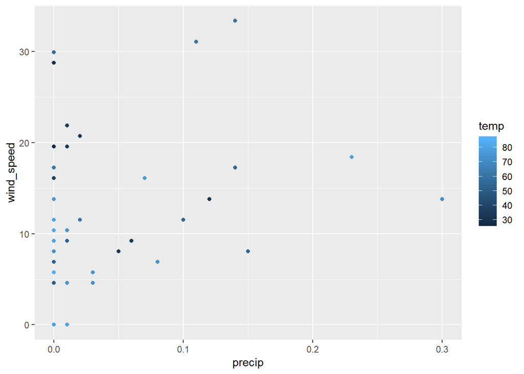

```r
ggplot(weather_most_delayed, aes(x = precip, y = wind_speed, color = temp)) +
  geom_point()
```

It’s hard to say much more than that without using the tools from [Exploratory Data Analysis](https://r4ds.had.co.nz/exploratory-data-analysis.html#covariation) section to look for covariation between weather and flight delays using all flights. Implicitly in my informal analysis of trends in weather using only the 48 hours with the worst delays, I was comparing the weather in these hours to some belief I had about what constitutes “normal” or “good” weather. It would be better to actually use data to make that comparison.

# 5.What does anti_join(flights, airports, by = c(“dest” = “faa”)) tell you? What does anti_join(airports, flights, by = c(“faa” = “dest”)) tell you?

`anti_join(flights, airports, by = c("dest" = "faa"))` are flights that go to an airport that is not in the FAA list of destinations. Since the FAA list only contains domestic airports, these are likely foreign flights.

`anti_join(airports, flights, by = c("faa" = "dest"))` are US airports that were not a destination of any any flight in the data. Since the data contains all flights from New York City airports, this is the list of US airports that did not have a direct flight from New York City in 2013. #6.You might expect that there’s an implicit relationship between plane and airline, because each plane is flown by a single airline. Confirm or reject this hypothesis using the tools you’ve learned above. At each point in time, each plane is flown by a single airline. However, a plane can be sold and fly for multiple airlines. Logically, it is possible that a plane can fly for multiple airlines over the course of its lifetime. But, it is not necessarily the case that a plane will fly for more than one airline in this data, especially since it comprises only a year of data. So let’s check to see if there are any planes in the data flew for multiple airlines.

First, find all distinct airline, plane combinations.

```r
planes_carriers <-
  flights %>%
  filter(!is.na(tailnum)) %>%
  distinct(tailnum, carrier)
```

The number of planes that have flown for more than one airline are those `tailnum` that appear more than once in the `planes_carriers` data.

```r
planes_carriers %>%
  count(tailnum) %>%
  filter(n > 1) %>%
  nrow()
```

```
## [1] 17
```

The names of airlines are easier to understand than the two-letter carrier codes. The `airlines` data frame contains the names of the airlines.

```r
carrier_transfer_tbl <- planes_carriers %>%
  # keep only planes which have flown for more than one airline
  group_by(tailnum) %>%
  filter(n() > 1) %>%
  # join with airlines to get airline names
  left_join(airlines, by = "carrier") %>%
  arrange(tailnum, carrier)
carrier_transfer_tbl
```

```
## # A tibble: 34 x 3
## # Groups:   tailnum [17]
##    tailnum carrier name
##    <chr>   <chr>   <chr>
##  1 N146PQ  9E      Endeavor Air Inc.
##  2 N146PQ  EV      ExpressJet Airlines Inc.
##  3 N153PQ  9E      Endeavor Air Inc.
##  4 N153PQ  EV      ExpressJet Airlines Inc.
##  5 N176PQ  9E      Endeavor Air Inc.
##  6 N176PQ  EV      ExpressJet Airlines Inc.
##  7 N181PQ  9E      Endeavor Air Inc.
##  8 N181PQ  EV      ExpressJet Airlines Inc.
##  9 N197PQ  9E      Endeavor Air Inc.
## 10 N197PQ  EV      ExpressJet Airlines Inc.
## # ... with 24 more rows
```

# 14.2.5 Exercises

# 1.In code that doesn’t use stringr, you’ll often see paste() and paste0(). What’s the difference between the two functions? What stringr function are they equivalent to? How do the functions differ in their handling of NA?

The function `paste()` separates strings by spaces by default, while `paste0()` does not separate strings with spaces by default.

```r
paste("foo", "bar")
```

```
## [1] "foo bar"
```

```r
paste0("foo", "bar")
```

```
## [1] "foobar"
```

Since `str_c()` does not separate strings with spaces by default it is closer in behavior to `paste0()`.

```r
str_c("foo", "bar")
```

```
## [1] "foobar"
```

However, `str_c()` and the paste function handle NA differently. The function `str_c()` propagates `NA`, if any argument is a missing value, it returns a missing value. This is in line with how the numeric R functions, e.g. `sum()`, `mean()`, handle missing values. However, the paste functions, convert `NA` to the string `"NA"` and then treat it as any other character vector.

```r
str_c("foo", NA)
```

```
## [1] NA
```

```r
paste("foo", NA)
```

```
## [1] "foo NA"
```

```r
paste0("foo", NA)
```

```
## [1] "fooNA"
```

# 2.In your own words, describe the difference between the sep and collapse arguments to str_c().

The `sep` argument is the string inserted between arguments to `str_c()`, while `collapse` is the string used to separate any elements of the character vector into a character vector of length one.

# 3.Use str_length() and str_sub() to extract the middle character from a string. What will you do if the string has an even number of characters?

The following function extracts the middle character. If the string has an even number of characters the choice is arbitrary. We choose to select $\lceil n / 2 \rceil$, because that case works even if the string is only of length one. A more general method would allow the user to select either the floor or ceiling for the middle character of an even string.

```r
x <- c("a", "abc", "abcd", "abcde", "abcdef")
L <- str_length(x)
m <- ceiling(L / 2)
str_sub(x, m, m)
```

```
## [1] "a" "b" "b" "c" "c"
```

# 4.What does str_wrap() do? When might you want to use it?

The function `str_wrap()` wraps text so that it fits within a certain width. This is useful for wrapping long strings of text to be typeset.

# 5.What does str_trim() do? What’s the opposite of str_trim()?

The function `str_trim()` trims the whitespace from a string.

```r
str_trim(" abc ")
```

```
## [1] "abc"
```

```r
str_trim(" abc ", side = "left")
```

```
## [1] "abc "
```

```r
str_trim(" abc ", side = "right")
```

```
## [1] " abc"
```

The opposite of `str_trim()` is `str_pad()` which adds characters to each side.

```r
str_pad("abc", 5, side = "both")
```

```
## [1] " abc "
```

```r
str_pad("abc", 4, side = "right")
```

```
## [1] "abc "
```

```r
str_pad("abc", 4, side = "left")
```

```
## [1] " abc"
```